# 2348538_LAB1

```python
import librosa
import numpy as np
import matplotlib.pyplot as plt
import seaborn as sns
from scipy.signal import resample
from scipy.interpolate import interp1d
```

```
Sampling Rate: 16000 Hz
Signal Length: 492960 samples
```

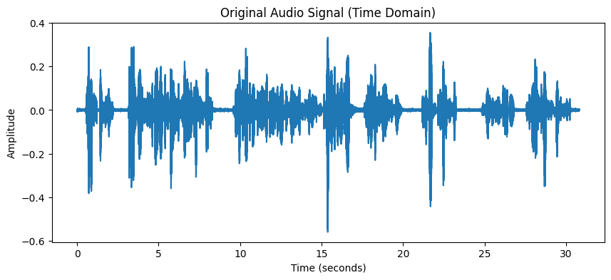

```python
# Load the audio file
file_path = 'D:/SEM 5/SPR/672-122797-0008.wav'
signal, sr = librosa.load(file_path, sr=None)

# Print audio file details
print(f"Sampling Rate: {sr} Hz")
print(f"Signal Length: {len(signal)} samples")

# Plot the original audio signal
duration = len(signal) / sr
plt.figure(figsize=(10, 4))
plt.plot(np.linspace(0, duration, len(signal)), signal)
plt.title('Original Audio Signal (Time Domain)')
plt.xlabel('Time (seconds)')
plt.ylabel('Amplitude')
plt.show()
```

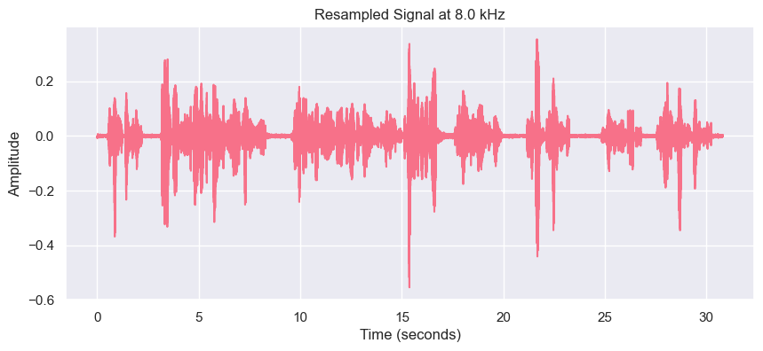

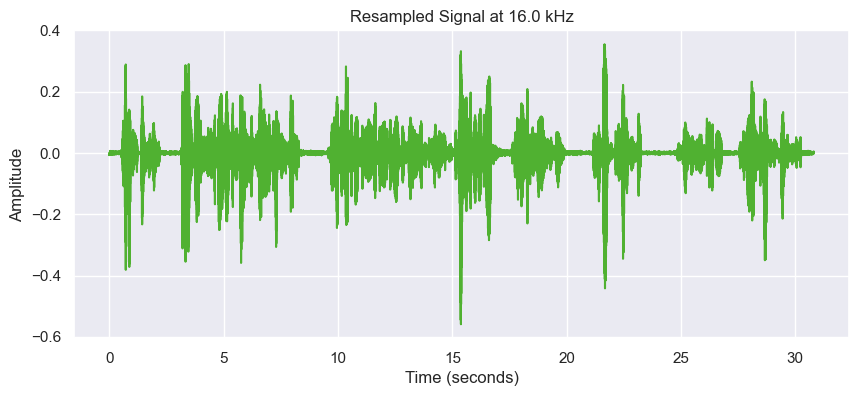

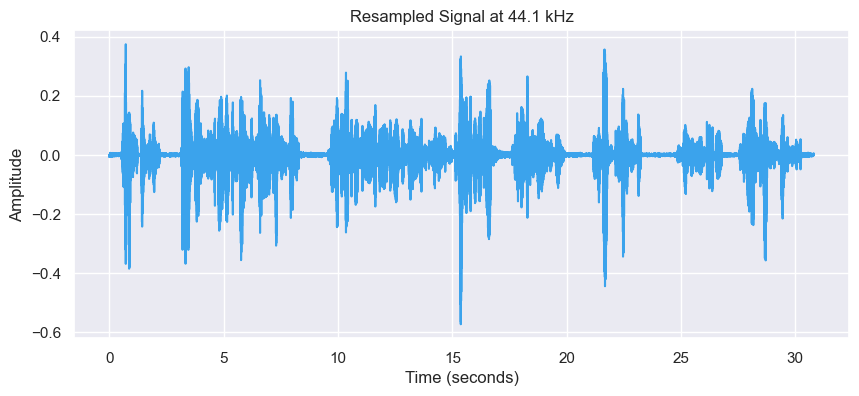

```python
sampling_rates = [8000, 16000, 44100]
resampled_signals = {}

for sr_target in sampling_rates:
    resampled_signals[sr_target] = librosa.resample(signal, orig_sr=sr, target_sr=sr_target)

# Plot the resampled signals using Seaborn
sns.set(style="darkgrid")
colors = sns.color_palette("husl", len(sampling_rates))

for i, (sr_target, resampled_signal) in enumerate(resampled_signals.items()):
    plt.figure(figsize=(10, 4))
    sns.lineplot(x=np.linspace(0, duration, len(resampled_signal)), y=resampled_signal, color=colors[i])
    plt.title(f'Resampled Signal at {sr_target / 1000} kHz')
    plt.xlabel('Time (seconds)')
    plt.ylabel('Amplitude')
    plt.show()
```

# (d) Using the sampled signals from the above task, reconstruct the signal using:

(i) Zero-order hold (nearest-neighbor interpolation) (ii) Linear interpolation.

# (e) Calculate the Mean Squared Error (MSE) between the original and the reconstructed signals for both methods.

- Reconstructing Using Zero-Order Hold: This method replicates the value of each sample until the next sample. It's essentially a piecewise constant approximation.
- Reconstructing Using Linear Interpolation: This method linearly interpolates between samples to create a continuous signal.

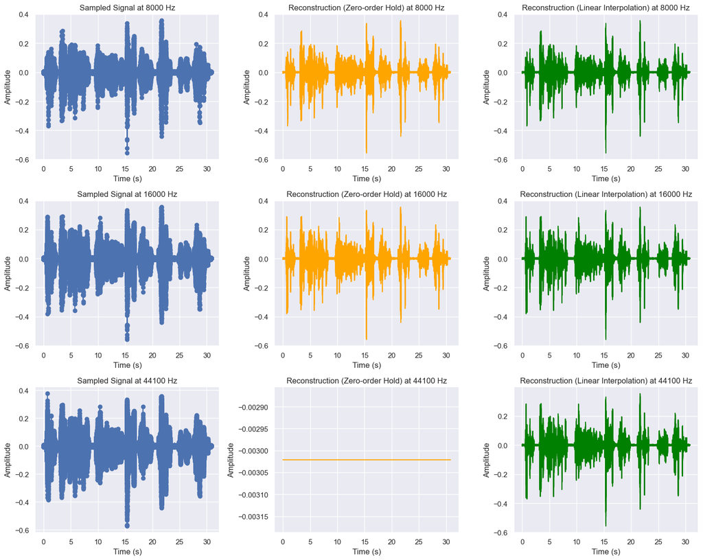

```
MSE (Zero-order Hold): [0.0001991313, 0.0, 0.0010015761]
MSE (Linear Interpolation): [0.00012434373238703016, 2.343136084886983e-37, 3.083113994457577e-07]
```

```python
file_path = r'D:\SEM 5\SPR\672-122797-0008.wav'
original_signal, sr = librosa.load(file_path, sr=None)  # Load with the original sampling rate


# Define the Mean Squared Error function
def calculate_mse(original, reconstructed):
    return np.mean((original - reconstructed) ** 2)

# Define the duration based on the loaded signal
duration = len(original_signal) / sr

# Sampling rates to downsample the original signal
sampling_rates = [8000, 16000, 44100]

# Storage for MSE values
mse_zero_order_hold = []
mse_linear_interpolation = []

plt.figure(figsize=(15, 12))
for i, new_sr in enumerate(sampling_rates):
    # Resample the signal to new sampling rate
    if new_sr != sr:
        num_samples = int(len(original_signal) * new_sr / sr)
        sampled_signal = resample(original_signal, num_samples)
        t_new = np.linspace(0, duration, num_samples, endpoint=False)
    else:
        sampled_signal = original_signal
        t_new = np.linspace(0, duration, len(sampled_signal), endpoint=False)

    # Zero-order Hold (Nearest neighbor interpolation)
    t_zh = np.linspace(0, duration, len(original_signal), endpoint=False)
    nearest_interp = np.floor_divide(np.arange(len(t_zh)), len(t_zh) // len(t_new))
    zero_order_hold = sampled_signal[nearest_interp]

    # Linear interpolation
    linear_interp_func = interp1d(t_new, sampled_signal, kind='linear', fill_value="extrapolate")
    linear_interp = linear_interp_func(t_zh)

    # Calculate MSE for Zero-Order Hold
    mse_zh = calculate_mse(original_signal[:len(zero_order_hold)], zero_order_hold)
    mse_zero_order_hold.append(mse_zh)

    # Calculate MSE for Linear Interpolation
    mse_li = calculate_mse(original_signal[:len(linear_interp)], linear_interp)
    mse_linear_interpolation.append(mse_li)

    # Plot the sampled signals
    plt.subplot(len(sampling_rates), 3, i * 3 + 1)
    plt.plot(t_new, sampled_signal, 'o-', label='Sampled')
    plt.title(f"Sampled Signal at {new_sr} Hz")
    plt.xlabel("Time (s)")
    plt.ylabel("Amplitude")
    plt.grid(True)

    # Plot Zero-order Hold Reconstruction
    plt.subplot(len(sampling_rates), 3, i * 3 + 2)
    plt.plot(t_zh, zero_order_hold, label="Zero-order Hold", color='orange')
    plt.title(f"Reconstruction (Zero-order Hold) at {new_sr} Hz")
    plt.xlabel("Time (s)")
    plt.ylabel("Amplitude")
    plt.grid(True)

    # Plot Linear Interpolation Reconstruction
    plt.subplot(len(sampling_rates), 3, i * 3 + 3)
    plt.plot(t_zh, linear_interp, label='Linear Interpolation', color='green')
    plt.title(f"Reconstruction (Linear Interpolation) at {new_sr} Hz")
    plt.xlabel("Time (s)")
    plt.ylabel("Amplitude")
    plt.grid(True)

plt.tight_layout()
plt.show()

# Print the MSE results
print("MSE (Zero-order Hold):", mse_zero_order_hold)
print("MSE (Linear Interpolation):", mse_linear_interpolation)
```

```python
# Print MSE values
print("Mean Squared Error (MSE) between original and reconstructed signals:")
for i, new_sr in enumerate(sampling_rates):
    print(f"Sampling Rate: {new_sr} Hz")
    print(f"  Zero-Order Hold MSE: {mse_zero_order_hold[i]}")
    print(f"  Linear Interpolation MSE: {mse_linear_interpolation[i]}")
```

```
Mean Squared Error (MSE) between original and reconstructed signals:
Sampling Rate: 8000 Hz
  Zero-Order Hold MSE: 0.00019913130381610245
  Linear Interpolation MSE: 0.00012434373238703016
Sampling Rate: 16000 Hz
  Zero-Order Hold MSE: 0.0
  Linear Interpolation MSE: 2.343136084886983e-37
Sampling Rate: 44100 Hz
  Zero-Order Hold MSE: 0.0010015760781243443
  Linear Interpolation MSE: 3.083113994457577e-07
```

## Mean Squared Error (MSE) between Original and Reconstructed Signals

### 1. **Sampling Rate: 8000 Hz**

- **Zero-Order Hold MSE:** `0.000199`
  - The zero-order hold (nearest neighbor interpolation) introduces a small error compared to the original signal at this sampling rate. Since 8000 Hz is lower than the original rate, some fine details of the audio signal are lost, leading to noticeable reconstruction errors.
- **Linear Interpolation MSE:** `0.000124`
  - Linear interpolation performs better than zero-order hold, with a lower error. This suggests that linear interpolation is more effective in reconstructing the signal at 8000 Hz, as it provides a smoother approximation by interpolating between sample points.

### 2. **Sampling Rate: 16000 Hz**

- **Zero-Order Hold MSE:** `0.0`
  - At 16000 Hz, the zero-order hold perfectly reconstructs the original signal with zero error. This likely indicates that the original signal's sampling rate was also 16000 Hz, leading to no loss of information.
- **Linear Interpolation MSE:** `2.34e-37` (approximately 0)
  - The MSE for linear interpolation is essentially zero, confirming that the reconstructed signal using linear interpolation is nearly identical to the original. This further suggests that 16000 Hz matches the original sampling rate.

### **General Observations:**

This suggests that using linear interpolation for resampling provides better results than zero-order hold, especially when working with sampling rates different from the original signal.

# (2) Implement the source-filter Model for a given speech signal and analyze the impact of sampling and reconstruction on the quality of the speech signal.

(a) Generate a synthetic speech signal using the source-filter model.

(i) Create a source signal (e.g., a glottal pulse train for voiced sounds or white noise for unvoiced sounds).

(ii) Apply a filter that models the vocal tract, represented by an all-pole filter or an FIR filter with formants (resonances of the vocal tract).

### The source-filter model is a fundamental representation of speech production, which separates the source of sound (glottal pulse or noise) from the filter (vocal tract).

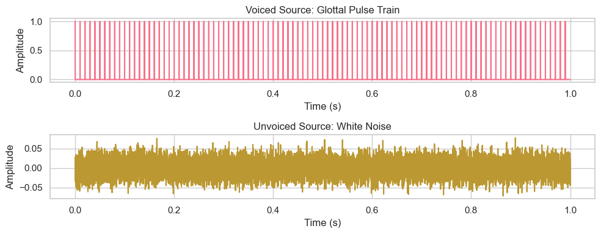

```python
# Create the Source Signal
from scipy.signal import lfilter, butter

# Parameters
sr = 16000  # Sampling rate (16 kHz)
duration = 1.0  # Duration of the signal in seconds
t = np.linspace(0, duration, int(sr * duration), endpoint=False)

# Voiced source: Glottal pulse train (simple periodic pulse train)
f0 = 100  # Fundamental frequency for voiced sound
glottal_pulse_train = np.zeros_like(t)
pulse_period = int(sr / f0)
glottal_pulse_train[::pulse_period] = 1  # Generate a pulse train

# Unvoiced source: White noise for fricative sounds
unvoiced_noise = np.random.randn(len(t)) * 0.02

sns.set_style("whitegrid")
colors = sns.color_palette("husl")

# Plot the source signals
plt.figure(figsize=(10, 4))
plt.subplot(2, 1, 1)
sns.lineplot(x=t, y=glottal_pulse_train, color=colors[0])
plt.title("Voiced Source: Glottal Pulse Train")
plt.xlabel("Time (s)")
plt.ylabel("Amplitude")

plt.subplot(2, 1, 2)
sns.lineplot(x=t, y=unvoiced_noise, color=colors[1])
plt.title("Unvoiced Source: White Noise")
plt.xlabel("Time (s)")
plt.ylabel("Amplitude")
plt.tight_layout()
plt.show()
```

# Apply a Vocal Tract Filter (All-Pole Filter with Formants)

Formants (resonances of the vocal tract) are modeled using an all-pole filter. We'll simulate three formants for a vowel sound.

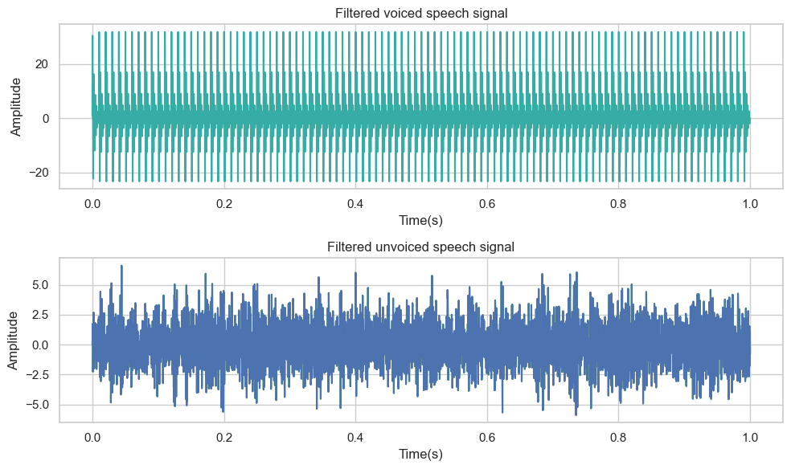

```python
formants = [500, 1500, 2500]
bandwidths = [100, 100, 100]

#create an all-pole filter for the vocal tract
def create_vocal_tract_filter(formants, bandwidths, sr):
  b, a = 1, 1 #initialize filter coefficients
  for f, bw in zip(formants, bandwidths):
    omega = 2 * np.pi * f / sr
    r = np.exp(-np.pi * bw / sr)
    pole = [1,-2 * r * np.cos(omega), r**2] # All pole filter coefficients
    b = np.convolve(b, [1])
    a = np.convolve(a, pole)
  return b, a

# Apply the vocal tract filter
b, a = create_vocal_tract_filter(formants, bandwidths, sr)
filtered_voiced = lfilter(b, a, glottal_pulse_train)
filtered_unvoiced = lfilter(b, a, unvoiced_noise)

#plot the filtered signals
plt.figure(figsize=(10,6))
plt.subplot(2,1,1)
sns.lineplot(x=t, y=filtered_voiced, color=colors[3])
plt.title("Filtered voiced speech signal")
plt.xlabel("Time(s)")
plt.ylabel("Amplitude")

plt.subplot(2,1,2)
sns.lineplot(x=t, y=filtered_unvoiced, color=colors[2])
plt.plot(t, filtered_unvoiced)
plt.title("Filtered unvoiced speech signal")
plt.xlabel("Time(s)")
plt.ylabel("Amplitude")
plt.tight_layout()
plt.show()
```

The glottal pulse train becomes smoother, simulating the resonances in the vocal tract.

The white noise also becomes filtered, emphasizing specific frequency components.

# (c)Sample the Speech Signal at Different Rates

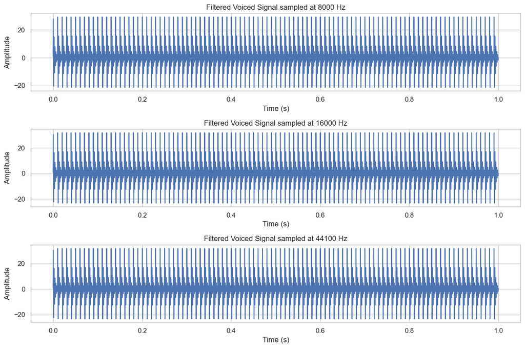

```python
from scipy.signal import resample

sampling_rates = [8000, 16000, 44100]

plt.figure(figsize=(12,8))
for i, new_sr in enumerate(sampling_rates):
    num_samples = int(len(filtered_voiced) * new_sr / sr)
    sampled_signal = resample(filtered_voiced, num_samples)
    t_new = np.linspace(0, duration, num_samples, endpoint=False)

    plt.subplot(len(sampling_rates), 1, i + 1)
    plt.plot(t_new, sampled_signal)
    plt.title(f"Filtered Voiced Signal sampled at {new_sr} Hz")
    plt.xlabel("Time (s)")
    plt.ylabel("Amplitude")
    plt.grid(True)

plt.tight_layout()
plt.show()
```

Sampling is typically applied to the filtered voiced signal rather than the unvoiced signal in the context of speech processing because voiced speech exhibits a more periodic structure, which makes the effects of sampling more apparent and critical for speech quality.